# Análisis Exploratorio de Precios Mayoristas Agropecuarios en Colombia - SIPSA-P 2024

Diego Fernando Irreño Torres - Diego Alexander Irreño Rodriguez

2026-06-06

# 1 Introducción

## 1.1 Planteamiento del Problema

La seguridad alimentaria y la estabilidad de los precios de los alimentos son pilares fundamentales para el desarrollo económico y social de Colombia. El acceso a información confiable, oportuna y de calidad sobre los precios mayoristas de los alimentos permite a productores, comercializadores, tomadores de decisiones de política pública y ciudadanía en general, comprender la dinámica del mercado agropecuario nacional.

El Sistema de Información de Precios y Abastecimiento del Sector Agropecuario — Componente de Precios Mayoristas (**SIPSA-P**), administrado por el Departamento Administrativo Nacional de Estadística (**DANE**), recopila diariamente información sobre precios de venta mayorista de una canasta de alimentos frescos y procesados en los principales mercados mayoristas del país.

Sin embargo, los datos recolectados en campo frecuentemente presentan desafíos relacionados con:

- **Datos faltantes**: ausencia de precios en ciertos mercados o períodos.
- **Registros duplicados**: observaciones repetidas producto del proceso de digitación.
- **Inconsistencias en variables categóricas**: diferencias en la escritura de nombres de mercados, grupos y productos.
- **Valores atípicos**: precios inusualmente bajos o altos que pueden distorsionar el análisis.

El problema consiste en **realizar un proceso completo de limpieza, estandarización y análisis exploratorio del conjunto de datos SIPSA-P correspondiente al año 2024**, con el fin de obtener un dataset confiable que permita identificar patrones de comportamiento de los precios mayoristas de alimentos a nivel nacional y por mercado.

## 1.2 Objetivo General

Desarrollar un proceso completo de carga, limpieza y análisis exploratorio de datos (EDA) sobre el conjunto de datos SIPSA-P 2024, que permita describir el comportamiento de los precios mayoristas de alimentos en Colombia durante el año 2024, identificando los principales mercados, grupos de alimentos y productos según su precio promedio por kilogramo.

## 1.3 Objetivos Específicos

** Identificar las variables de interés**

- Seleccionar una variable cuantitativa (precio promedio por kilogramo) y una variable cualitativa (grupo de alimentos) para el análisis.

** Realizar limpieza de datos**

- Detectar y cuantificar valores faltantes.
- Eliminar registros duplicados.
- Limpiar y estandarizar formatos de texto en variables categóricas.
- Convertir correctamente variables de tipo numérico.

** Desarrollar el análisis exploratorio**

- Calcular estadísticos descriptivos para la variable cuantitativa.
- Generar visualizaciones (histogramas, boxplots, gráficos de barras).
- Identificar el Top 10 de mercados con mayor precio promedio por kilogramo.

** Documentar y comunicar los resultados**

- Presentar los hallazgos de manera clara y reproducible en formato R Markdown.

# 2 Descripción del Conjunto de Datos

## 2.1 Fuente

El conjunto de datos utilizado corresponde al archivo **SIPSA_P-Mensual-2024**, publicado por el DANE en su repositorio de microdatos (https://microdatos.dane.gov.co). Este archivo contiene información mensual de los precios mayoristas de alimentos recolectados durante el año 2024 en los principales mercados mayoristas de Colombia.

## 2.2 Descripción General

Según la documentación oficial (DDI), el componente SIPSA-P tiene por objeto generar información continua sobre el comportamiento de los precios de venta mayorista de una canasta de alimentos en mercados mayoristas del país. Los productos monitoreados pertenecen a ocho grupos:

1. Verduras y hortalizas
2. Frutas
3. Tubérculos, raíces y plátanos
4. Granos y cereales
5. Lácteos y huevos
6. Carnes
7. Pescados
8. Procesados

## 2.3 Variables del Dataset 2024

El archivo SIPSA_P-Mensual-2024 contiene **6 variables** y **54.042 registros**:

| Variable | Etiqueta | Tipo |
| --- | --- | --- |
| `Fecha` | Fecha Programada para la Recolección | Carácter (mes-año) |
| `Grupo` | ID Grupo de alimentos | Carácter |
| `Producto` | Nombre del artículo | Carácter |
| `CODIGO_CPC_AC` | Código CPC del producto | Carácter |
| `Mercado` | Nombre del mercado mayorista | Carácter |
| `Precio_promedio_por_kilogramo` | Precio promedio diario (COP/kg) | Numérico |

## 2.4 Variables Seleccionadas para el Análisis

- **Variable cuantitativa**: `Precio_promedio_por_kilogramo` — precio mayorista promedio expresado en pesos colombianos por kilogramo (COP/kg).
- **Variable cualitativa**: `Grupo` — categoría del grupo de alimentos al que pertenece el producto.
- **Código geográfico/mercado**: `Mercado` — nombre del mercado mayorista, que incluye el municipio o ciudad de referencia.

#Carga de Librerías y Datos

## 2.5 Cargar Librerías

```r
library(readr)      # lectura de archivos CSV
library(dplyr)      # manipulación de datos
library(ggplot2)    # visualizaciones
library(stringr)    # manipulación de texto
library(tidyr)      # transformación de datos
library(knitr)      # tablas en RMarkdown
```

## 2.6 Cargar el Dataset

```r
list.files("../Datos") # Verificar que archivos están en el proyecto
```

```
## [1] "mensual 24.csv"
```

```r
data_raw <- read.csv(
  "C:\\Users\\MSI\\Desktop\\Ejercicio clase 2\\datos\\mensual 24.csv",
  sep = ";",
  fileEncoding = "UTF-8-BOM",
  stringsAsFactors = FALSE,
  check.names = FALSE
)
```

## 2.7 Estandarizar Nombres de Columnas

```r
# Estandarizar nombres de columnas
data <- data_raw
colnames(data) <- c("Fecha", "Grupo", "Producto", "Codigo_CPC", "Mercado", "Precio_kg")
```

```r
# Limpiar y convertir la variable precio a numérico
# (el archivo usa punto como separador de miles: 1.387 = 1387 pesos)
data$Precio_kg <- trimws(data$Precio_kg)           # eliminar espacios
data$Precio_kg <- gsub("[.]", "", data$Precio_kg)  # eliminar separador de miles
data$Precio_kg <- as.numeric(data$Precio_kg)        # convertir a numérico
```

# 3 Exploración Inicial de los Datos

## 3.1 Visualización de los Primeros Registros

```r
head(data)
```

```
##    Fecha                 Grupo Producto Codigo_CPC                      Mercado
## 1 ene-24 VERDURAS Y HORTALIZAS   Acelga    0121903              Armenia, Mercar
## 2 ene-24 VERDURAS Y HORTALIZAS   Acelga    0121903     Bogotá, D.C., Corabastos
## 3 ene-24 VERDURAS Y HORTALIZAS   Acelga    0121903   Bucaramanga, Centroabastos
## 4 ene-24 VERDURAS Y HORTALIZAS   Acelga    0121903        Chiquinquirá (Boyacá)
## 5 ene-24 VERDURAS Y HORTALIZAS   Acelga    0121903 Duitama (Boyacá), Mercaplaza
## 6 ene-24 VERDURAS Y HORTALIZAS   Acelga    0121903          Florencia (Caquetá)
##   Precio_kg
## 1      1387
## 2       607
## 3         2
## 4      1896
## 5         2
## 6       265
```

## 3.2 Visualización de los Últimos Registros

```r
tail(data)
```

```
##        Fecha      Grupo Producto Codigo_CPC                       Mercado
## 54037 dic-24 PROCESADOS  Vinagre    2399401        Cúcuta, La Nueva Sexta
## 54038 dic-24 PROCESADOS  Vinagre    2399401     Montería, Mercado del Sur
## 54039 dic-24 PROCESADOS  Vinagre    2399401 Pamplona (Norte de Santander)
## 54040 dic-24 PROCESADOS  Vinagre    2399401       Santa Marta (Magdalena)
## 54041 dic-24 PROCESADOS  Vinagre    2399401      Sincelejo, Nuevo Mercado
## 54042 dic-24 PROCESADOS  Vinagre    2399401     Valledupar, Mercado Nuevo
##       Precio_kg
## 54037      2285
## 54038      1708
## 54039      1833
## 54040      1525
## 54041      1302
## 54042      1361
```

## 3.3 Dimensiones del Dataset

```r
dim(data)
```

```
## [1] 54042     6
```

El dataset contiene **54042 registros** y **6 variables**, lo que corresponde a la información de precios mayoristas de alimentos recolectada durante los 12 meses del año 2024 en los mercados mayoristas de Colombia.

## 3.4 Estructura de los Datos

```r
str(data)
```

```
## 'data.frame':    54042 obs. of  6 variables:
##  $ Fecha     : chr  "ene-24" "ene-24" "ene-24" "ene-24" ...
##  $ Grupo     : chr  "VERDURAS Y HORTALIZAS" "VERDURAS Y HORTALIZAS" "VERDURAS Y HORTALIZAS" "VERDURAS Y HORTALIZAS" ...
##  $ Producto  : chr  "Acelga" "Acelga" "Acelga" "Acelga" ...
##  $ Codigo_CPC: chr  "0121903" "0121903" "0121903" "0121903" ...
##  $ Mercado   : chr  "Armenia, Mercar" "Bogotá, D.C., Corabastos" "Bucaramanga, Centroabastos" "Chiquinquirá (Boyacá)" ...
##  $ Precio_kg : num  1387 607 2 1896 2 ...
```

## 3.5 Nombre de las Columnas

```r
colnames(data)
```

```
## [1] "Fecha"      "Grupo"      "Producto"   "Codigo_CPC" "Mercado"
## [6] "Precio_kg"
```

## 3.6 Frecuencia por Grupo de Alimentos

```r
tabla_grupo <- data.frame(sort(table(data$Grupo), decreasing = TRUE))
colnames(tabla_grupo) <- c("Grupo", "Frecuencia")
tabla_grupo
```

```
##                           Grupo Frecuencia
## 1                        FRUTAS      12891
## 2         VERDURAS Y HORTALIZAS      11112
## 3                        CARNES       8685
## 4                    PROCESADOS       8544
## 5 TUBERCULOS, RAICES Y PLATANOS       3956
## 6             GRANOS Y CEREALES       3615
## 7                      PESCADOS       2918
## 8              LACTEOS Y HUEVOS       2321
```

## 3.7 Frecuencia por Mes (Variable Fecha)

```r
tabla_fecha <- data.frame(sort(table(data$Fecha), decreasing = TRUE))
colnames(tabla_fecha) <- c("Mes", "Frecuencia")
tabla_fecha
```

```
##       Mes Frecuencia
## 1  nov-24       4519
## 2  may-24       4514
## 3  dic-24       4512
## 4  ago-24       4510
## 5  feb-24       4508
## 6  ene-24       4504
## 7  jul-24       4503
## 8  mar-24       4500
## 9  oct-24       4499
## 10 abr-24       4495
## 11 jun-24       4493
## 12 sep-24       4485
```

La distribución mensual de registros es relativamente uniforme a lo largo del año, lo que indica consistencia en el proceso de recolección de la información durante el 2024.

# 4 Limpieza de Datos

## 4.1 Conversión de la Variable Precio

La variable `Precio_kg` contiene los precios en formato texto con **puntos como separadores de miles** (ej: `1.387` equivale a 1.387 pesos colombianos por kilogramo) y espacios en blanco adicionales. Se debe limpiar y convertir a formato numérico.

```r
# Eliminar espacios, remover puntos separadores de miles y convertir a numérico
data$Precio_kg <- trimws(data$Precio_kg)             # eliminar espacios
data$Precio_kg <- gsub("[.]", "", data$Precio_kg)    # eliminar separador de miles
data$Precio_kg <- as.numeric(data$Precio_kg)         # convertir a numérico
```

## 4.2 Datos Perdidos

### 4.2.1 Total de Datos Perdidos

```r
total_na <- sum(is.na(data))
print(paste("Total de datos perdidos en el dataset:", total_na))
```

```
## [1] "Total de datos perdidos en el dataset: 0"
```

### 4.2.2 Datos Perdidos por Columna

```r
na_por_columna <- colSums(is.na(data))

tabla_na <- data.frame(
  Columna = names(na_por_columna),
  Datos_Perdidos = na_por_columna
)

tabla_na_ordenada <- tabla_na %>%
  filter(Columna != "Total") %>%
  arrange(desc(Datos_Perdidos)) %>%
  rbind(data.frame(Columna = "Total", Datos_Perdidos = total_na))

tabla_na_ordenada
```

```
##               Columna Datos_Perdidos
## Fecha           Fecha              0
## Grupo           Grupo              0
## Producto     Producto              0
## Codigo_CPC Codigo_CPC              0
## Mercado       Mercado              0
## Precio_kg   Precio_kg              0
## 1               Total              0
```

### 4.2.3 Tratamiento de Datos Faltantes

```r
# Excluir registros sin precio reportado
data_limpia <- data %>% filter(!is.na(Precio_kg))

print(paste("Registros antes de la exclusión:", nrow(data)))
```

```
## [1] "Registros antes de la exclusión: 54042"
```

```r
print(paste("Registros después de la exclusión:", nrow(data_limpia)))
```

```
## [1] "Registros después de la exclusión: 54042"
```

```r
print(paste("Registros eliminados:", nrow(data) - nrow(data_limpia)))
```

```
## [1] "Registros eliminados: 0"
```

## 4.3 Datos Duplicados

### 4.3.1 Total de Filas Duplicadas

```r
sum(duplicated(data_limpia))
```

```
## [1] 0
```

### 4.3.2 Mostrar Filas Duplicadas

```r
data_limpia[duplicated(data_limpia), ]
```

```
## [1] Fecha      Grupo      Producto   Codigo_CPC Mercado    Precio_kg
## <0 rows> (o 0- extensión row.names)
```

### 4.3.3 Eliminar Filas Duplicadas

```r
data_limpia <- data_limpia[!duplicated(data_limpia), ]

print(paste("Registros después de eliminar duplicados:", nrow(data_limpia)))
```

```
## [1] "Registros después de eliminar duplicados: 54042"
```

## 4.4 Estandarización de Variables Categóricas

Las variables de texto pueden presentar inconsistencias en el uso de mayúsculas, minúsculas y espacios. Se estandarizan para garantizar uniformidad.

```r
vars_categoricas <- c("Grupo", "Producto", "Mercado")

data_limpia[vars_categoricas] <- lapply(
  data_limpia[vars_categoricas],
  function(x) {
    x <- as.character(x)
    x <- trimws(x)                                          # eliminar espacios al inicio/fin
    x <- iconv(x, from = "UTF-8", to = "ASCII//TRANSLIT")  # quitar tildes
    x <- toupper(x)                                         # convertir a mayúsculas
    return(x)
  }
)
```

Verificación del grupo de alimentos después de la estandarización:

```r
unique(data_limpia$Grupo)
```

```
## [1] "VERDURAS Y HORTALIZAS"         "FRUTAS"
## [3] "TUBERCULOS, RAICES Y PLATANOS" "GRANOS Y CEREALES"
## [5] "LACTEOS Y HUEVOS"              "CARNES"
## [7] "PESCADOS"                      "PROCESADOS"
```

## 4.5 Extracción del Municipio/Ciudad desde la Variable Mercado

La columna `Mercado` contiene el nombre del municipio seguido del nombre del mercado mayorista separado por coma. Se extrae la primera parte para obtener el municipio de referencia.

```r
# Extraer la ciudad/municipio: todo lo que está antes de la primera coma
data_limpia$Ciudad <- str_trim(str_extract(data_limpia$Mercado, "^[^,]+"))

# Vista de los primeros valores extraídos
head(unique(data_limpia$Ciudad), 20)
```

```
##  [1] "ARMENIA"                        "BOGOTA"
##  [3] "BUCARAMANGA"                    "CHIQUINQUIRA (BOYACA)"
##  [5] "DUITAMA (BOYACA)"               "FLORENCIA (CAQUETA)"
##  [7] "IBAGUE"                         "IPIALES (NARINO)"
##  [9] "MEDELLIN"                       "NEIVA"
## [11] "PAMPLONA (NORTE DE SANTANDER)"  "PASTO"
## [13] "PEREIRA"                        "TIBASOSA (BOYACA)"
## [15] "TUNJA"                          "VILLAVICENCIO"
## [17] "YOPAL (CASANARE)"               "BARRANQUILLA"
## [19] "BUENAVENTURA (VALLE DEL CAUCA)" "CALI"
```

## 4.6 Resumen del Proceso de Limpieza

```r
cat("=== RESUMEN DE LIMPIEZA ===\n")
```

```
## === RESUMEN DE LIMPIEZA ===
```

```r
cat("Registros originales:               ", nrow(data), "\n")
```

```
## Registros originales:                54042
```

```r
cat("Registros con precio faltante:      ", sum(is.na(data$Precio_kg)), "\n")
```

```
## Registros con precio faltante:       0
```

```r
cat("Registros duplicados eliminados:    ", sum(duplicated(data_limpia)), "\n")
```

```
## Registros duplicados eliminados:     0
```

```r
cat("Registros finales para análisis:    ", nrow(data_limpia), "\n")
```

```
## Registros finales para análisis:     54042
```

```r
cat("Variables estandarizadas:           ", paste(vars_categoricas, collapse = ", "), "\n")
```

```
## Variables estandarizadas:            Grupo, Producto, Mercado
```

# 5 Análisis Exploratorio de Datos (EDA)

## 5.1 Estadísticos Descriptivos de la Variable Cuantitativa

La variable `Precio_kg` representa el **precio promedio mayorista en pesos colombianos (COP) por kilogramo** de los productos de la canasta SIPSA-P.

```r
summary(data_limpia$Precio_kg)
```

```
##    Min. 1st Qu.  Median    Mean 3rd Qu.    Max.
##       1    1438    3224    7843    9006  191528
```

```r
# Tabla de estadisticos descriptivos
estadisticos <- data.frame(
  Estadistico = c(
    "Media", "Mediana", "Desviacion Estandar",
    "Minimo", "Maximo",
    "Q1 (25%)", "Q2 (50%)", "Q3 (75%)",
    "Coeficiente de Variacion (%)"
  ),
  Valor = c(
    round(mean(data_limpia$Precio_kg, na.rm = TRUE), 2),
    round(median(data_limpia$Precio_kg, na.rm = TRUE), 2),
    round(sd(data_limpia$Precio_kg, na.rm = TRUE), 2),
    round(min(data_limpia$Precio_kg, na.rm = TRUE), 2),
    round(max(data_limpia$Precio_kg, na.rm = TRUE), 2),
    round(quantile(data_limpia$Precio_kg, 0.25, na.rm = TRUE), 2),
    round(quantile(data_limpia$Precio_kg, 0.50, na.rm = TRUE), 2),
    round(quantile(data_limpia$Precio_kg, 0.75, na.rm = TRUE), 2),
    round(
      (sd(data_limpia$Precio_kg, na.rm = TRUE) /
       mean(data_limpia$Precio_kg, na.rm = TRUE)) * 100, 2
    )
  )
)

kable(estadisticos, caption = "Estadísticos descriptivos: Precio promedio por kilogramo (COP/kg)")
```

Estadísticos descriptivos: Precio promedio por kilogramo (COP/kg)

| Estadistico | Valor |
| --- | --- |
| Media | 7842.96 |
| Mediana | 3224.00 |
| Desviacion Estandar | 12902.27 |
| Minimo | 1.00 |
| Maximo | 191528.00 |
| Q1 (25%) | 1438.00 |
| Q2 (50%) | 3224.00 |
| Q3 (75%) | 9005.75 |
| Coeficiente de Variacion (%) | 164.51 |

La variable `Precio_kg` presenta una distribución con alta dispersión. La media es considerablemente mayor que la mediana, lo que indica asimetría positiva y la posible presencia de valores atípicos en los extremos superiores, correspondientes a productos con precios muy elevados como carnes especiales o productos procesados. El coeficiente de variación elevado confirma la heterogeneidad de los precios entre los distintos productos y mercados monitoreados.

## 5.2 Histograma del Precio por Kilogramo

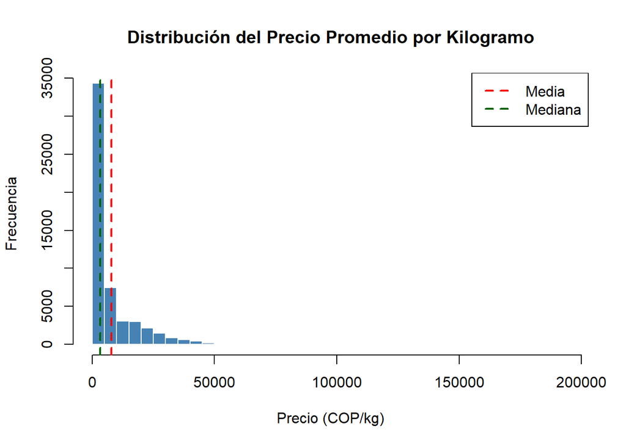

```r
hist(
  data_limpia$Precio_kg,
  col = "steelblue",
  border = "white",
  main = "Distribución del Precio Promedio por Kilogramo",
  xlab = "Precio (COP/kg)",
  ylab = "Frecuencia",
  breaks = 60
)
abline(v = mean(data_limpia$Precio_kg, na.rm = TRUE), col = "red", lwd = 2, lty = 2)
abline(v = median(data_limpia$Precio_kg, na.rm = TRUE), col = "darkgreen", lwd = 2, lty = 2)
legend("topright",
       legend = c("Media", "Mediana"),
       col = c("red", "darkgreen"),
       lty = 2, lwd = 2)
```

El histograma muestra una distribución fuertemente sesgada hacia la derecha (asimetría positiva). La gran mayoría de los precios se concentra en valores bajos, mientras que una pequeña proporción de productos presentan precios muy elevados. Esto es coherente con la naturaleza de la canasta SIPSA-P, donde productos básicos como verduras y tubérculos tienen precios menores, mientras que carnes y productos procesados pueden alcanzar precios notablemente superiores.

## 5.3 Histograma con Escala Logarítmica

Para visualizar mejor la distribución dada la asimetría, se aplica una transformación logarítmica:

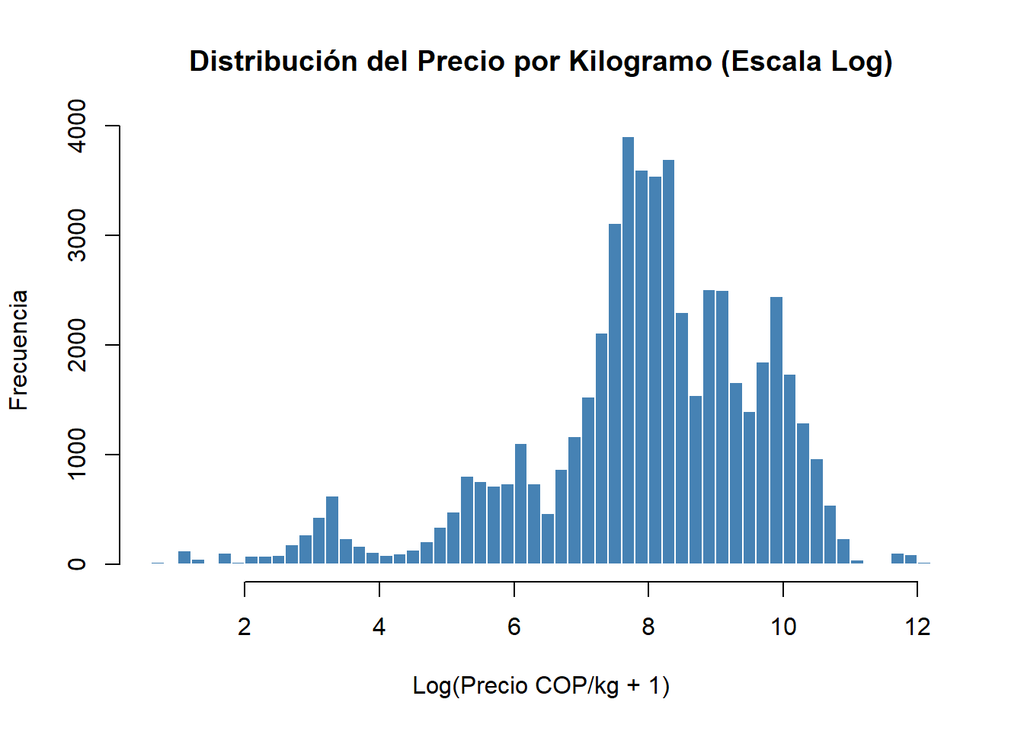

```r
hist(
  log(data_limpia$Precio_kg + 1),
  col = "steelblue",
  border = "white",
  main = "Distribución del Precio por Kilogramo (Escala Log)",
  xlab = "Log(Precio COP/kg + 1)",
  ylab = "Frecuencia",
  breaks = 50
)
```

## 5.4 Boxplot General del Precio por Kilogramo

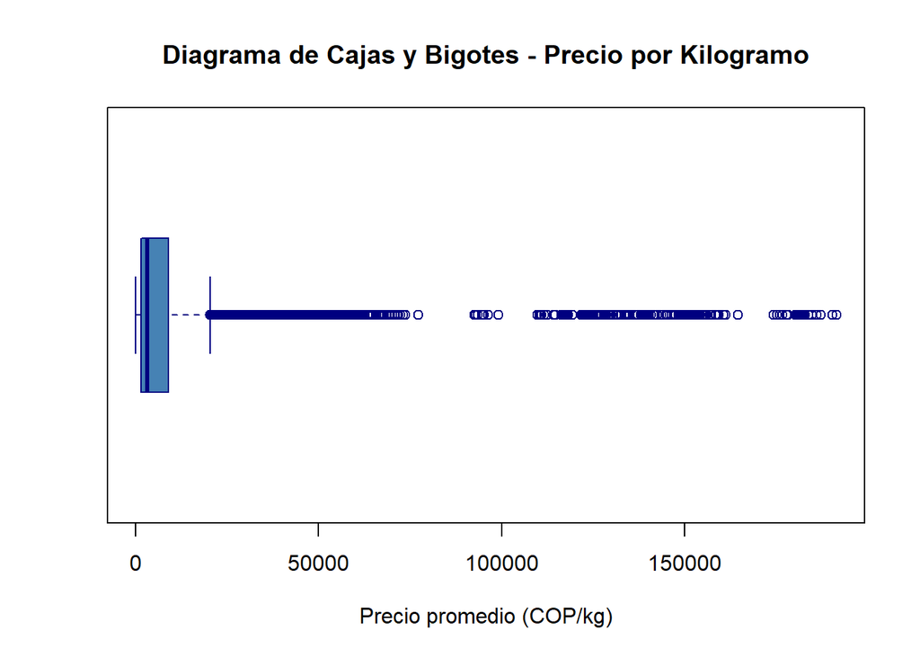

```r
boxplot(
  data_limpia$Precio_kg,
  horizontal = TRUE,
  col = "steelblue",
  border = "navy",
  main = "Diagrama de Cajas y Bigotes - Precio por Kilogramo",
  xlab = "Precio promedio (COP/kg)"
)
```

El diagrama de cajas confirma la alta dispersión de los precios y la presencia de numerosos valores atípicos en el extremo superior, que corresponden a productos con precios mayoristas especialmente elevados. La caja central (rango intercuartílico) agrupa la mayor concentración de precios, representando los productos de consumo masivo que conforman la canasta básica.

## 5.5 Boxplot por Grupo de Alimentos

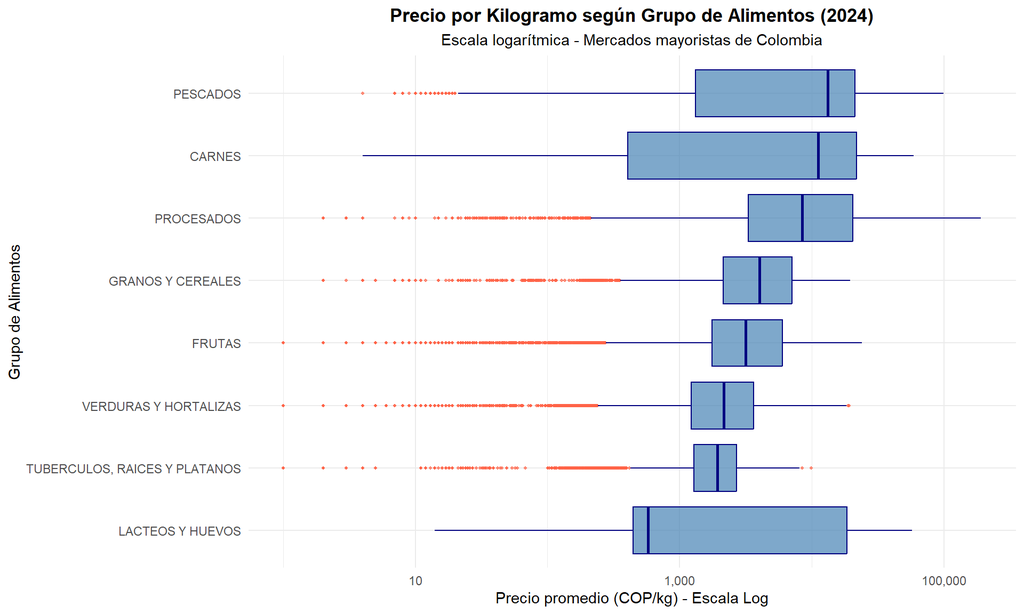

```r
ggplot(data_limpia, aes(x = reorder(Grupo, Precio_kg, FUN = median), y = Precio_kg)) +
  geom_boxplot(fill = "steelblue", color = "navy", outlier.colour = "tomato",
               outlier.size = 0.8, alpha = 0.7) +
  coord_flip() +
  scale_y_log10(labels = scales::comma) +
  labs(
    title = "Precio por Kilogramo según Grupo de Alimentos (2024)",
    subtitle = "Escala logarítmica - Mercados mayoristas de Colombia",
    x = "Grupo de Alimentos",
    y = "Precio promedio (COP/kg) - Escala Log"
  ) +
  theme_minimal() +
  theme(plot.title = element_text(hjust = 0.5, face = "bold"),
        plot.subtitle = element_text(hjust = 0.5))
```

## 5.6 Gráfico de Barras: Precio Promedio por Grupo de Alimentos

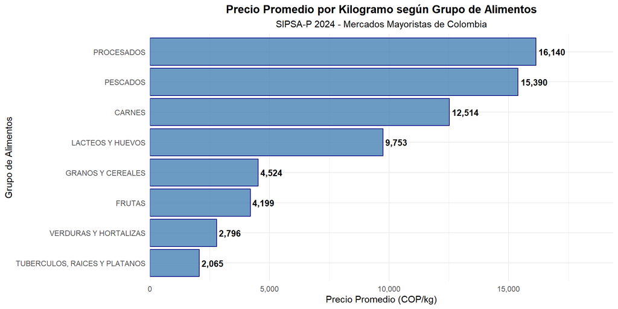

```r
precio_grupo <- data_limpia %>%
  group_by(Grupo) %>%
  summarise(Precio_Promedio = round(mean(Precio_kg, na.rm = TRUE), 0)) %>%
  arrange(desc(Precio_Promedio))

ggplot(precio_grupo, aes(x = reorder(Grupo, Precio_Promedio), y = Precio_Promedio)) +
  geom_bar(stat = "identity", fill = "steelblue", color = "navy", alpha = 0.8) +
  geom_text(aes(label = scales::comma(Precio_Promedio)),
            hjust = -0.1, size = 3.5, fontface = "bold") +
  coord_flip() +
  labs(
    title = "Precio Promedio por Kilogramo según Grupo de Alimentos",
    subtitle = "SIPSA-P 2024 - Mercados Mayoristas de Colombia",
    x = "Grupo de Alimentos",
    y = "Precio Promedio (COP/kg)"
  ) +
  scale_y_continuous(labels = scales::comma, expand = expansion(mult = c(0, 0.2))) +
  theme_minimal() +
  theme(plot.title = element_text(hjust = 0.5, face = "bold"),
        plot.subtitle = element_text(hjust = 0.5))
```

## 5.7 Evolución Mensual del Precio Promedio

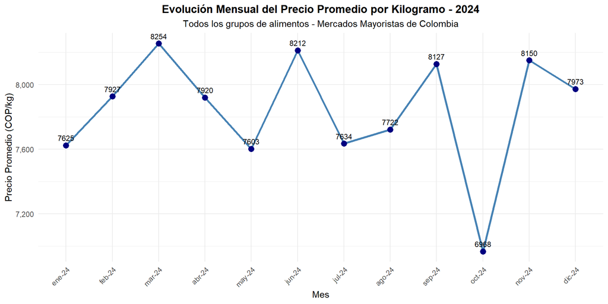

```r
# Ordenar los meses correctamente
orden_meses <- c("ene-24","feb-24","mar-24","abr-24","may-24","jun-24",
                 "jul-24","ago-24","sep-24","oct-24","nov-24","dic-24")

precio_mensual <- data_limpia %>%
  group_by(Fecha) %>%
  summarise(Precio_Promedio = mean(Precio_kg, na.rm = TRUE)) %>%
  mutate(Fecha = factor(Fecha, levels = orden_meses)) %>%
  arrange(Fecha)

ggplot(precio_mensual, aes(x = Fecha, y = Precio_Promedio, group = 1)) +
  geom_line(color = "steelblue", size = 1.2) +
  geom_point(color = "navy", size = 3) +
  geom_text(aes(label = round(Precio_Promedio, 0)),
            vjust = -0.8, size = 3.2) +
  labs(
    title = "Evolución Mensual del Precio Promedio por Kilogramo - 2024",
    subtitle = "Todos los grupos de alimentos - Mercados Mayoristas de Colombia",
    x = "Mes",
    y = "Precio Promedio (COP/kg)"
  ) +
  scale_y_continuous(labels = scales::comma) +
  theme_minimal() +
  theme(
    plot.title = element_text(hjust = 0.5, face = "bold"),
    plot.subtitle = element_text(hjust = 0.5),
    axis.text.x = element_text(angle = 45, hjust = 1)
  )
```

La evolución mensual muestra el comportamiento del precio promedio general de la canasta SIPSA-P a lo largo del 2024. Las variaciones observadas pueden relacionarse con factores estacionales, fenómenos climáticos (Fenómeno de El Niño/La Niña), dinámicas de oferta y demanda en los mercados regionales y coyunturas económicas del período.

## 5.8 Top 10 de Municipios/Ciudades con Mayor Precio Promedio

```r
top10_ciudad <- data_limpia %>%
  group_by(Ciudad) %>%
  summarise(
    Precio_Promedio = round(mean(Precio_kg, na.rm = TRUE), 0),
    N_Registros = n()
  ) %>%
  filter(N_Registros >= 50) %>%           # filtrar ciudades con datos suficientes
  arrange(desc(Precio_Promedio)) %>%
  head(10)

kable(top10_ciudad,
      col.names = c("Ciudad/Municipio", "Precio Promedio (COP/kg)", "N° Registros"),
      caption = "Top 10 ciudades con mayor precio promedio por kilogramo - SIPSA-P 2024",
      format.args = list(big.mark = ","))
```

Top 10 ciudades con mayor precio promedio por kilogramo - SIPSA-P 2024

| Ciudad/Municipio | Precio Promedio (COP/kg) | N° Registros |
| --- | --- | --- |
| BUENAVENTURA (VALLE DEL CAUCA) | 12,158 | 1,042 |
| BOGOTA | 12,077 | 5,672 |
| CALI | 10,941 | 3,535 |
| TULUA (VALLE DEL CAUCA) | 10,514 | 1,373 |
| SANTA MARTA (MAGDALENA) | 10,422 | 847 |
| BARRANQUILLA | 10,389 | 2,338 |
| MALAMBO (ATLANTICO) | 10,313 | 240 |
| MEDELLIN | 10,097 | 3,863 |
| CUCUTA | 9,953 | 2,368 |
| POPAYAN | 9,023 | 1,398 |

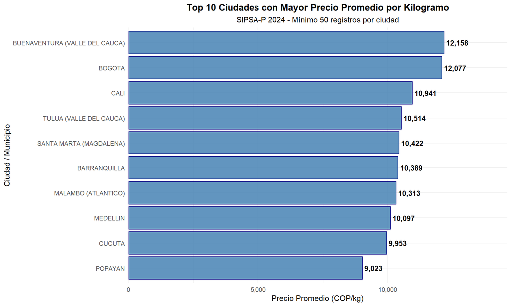

```r
ggplot(top10_ciudad, aes(x = reorder(Ciudad, Precio_Promedio), y = Precio_Promedio)) +
  geom_bar(stat = "identity", fill = "steelblue", color = "navy", alpha = 0.85) +
  geom_text(aes(label = scales::comma(Precio_Promedio)),
            hjust = -0.1, size = 3.5, fontface = "bold") +
  coord_flip() +
  labs(
    title = "Top 10 Ciudades con Mayor Precio Promedio por Kilogramo",
    subtitle = "SIPSA-P 2024 - Mínimo 50 registros por ciudad",
    x = "Ciudad / Municipio",
    y = "Precio Promedio (COP/kg)"
  ) +
  scale_y_continuous(labels = scales::comma, expand = expansion(mult = c(0, 0.2))) +
  theme_minimal() +
  theme(plot.title = element_text(hjust = 0.5, face = "bold"),
        plot.subtitle = element_text(hjust = 0.5))
```

## 5.9 Top 10 de Productos con Mayor Precio Promedio

```r
top10_producto <- data_limpia %>%
  group_by(Producto, Grupo) %>%
  summarise(Precio_Promedio = round(mean(Precio_kg, na.rm = TRUE), 0),
            .groups = "drop") %>%
  arrange(desc(Precio_Promedio)) %>%
  head(10)

kable(top10_producto,
      col.names = c("Producto", "Grupo", "Precio Promedio (COP/kg)"),
      caption = "Top 10 productos con mayor precio promedio por kilogramo - SIPSA-P 2024",
      format.args = list(big.mark = ","))
```

Top 10 productos con mayor precio promedio por kilogramo - SIPSA-P 2024

| Producto | Grupo | Precio Promedio (COP/kg) |
| --- | --- | --- |
| CAFE INSTANTANEO | PROCESADOS | 125,003 |
| LANGOSTINO U12 | PESCADOS | 61,392 |
| LANGOSTINO 16-20 | PESCADOS | 46,729 |
| MERLUZA, FILETE NACIONAL | PESCADOS | 44,332 |
| CORVINA, FILETE CONGELADO NACIONAL | PESCADOS | 42,872 |
| CHOCOLATE INSTANTANEO | PROCESADOS | 41,098 |
| LECHE EN POLVO | LACTEOS Y HUEVOS | 39,395 |
| GELATINA | PROCESADOS | 37,401 |
| ROBALO, FILETE CONGELADO | PESCADOS | 37,286 |
| SALMON, FILETE CONGELADO | PESCADOS | 37,139 |

```r
# Eliminar filas con precio faltante (NA)
data_limpia <- data[!is.na(data$Precio_kg), ]

print(paste("Registros originales:            ", nrow(data)))
```

```
## [1] "Registros originales:             54042"
```

```r
print(paste("Registros con precio faltante:   ", sum(is.na(data$Precio_kg))))
```

```
## [1] "Registros con precio faltante:    0"
```

```r
print(paste("Registros tras eliminar NA:      ", nrow(data_limpia)))
```

```
## [1] "Registros tras eliminar NA:       54042"
```

```r
# Eliminar filas duplicadas
data_limpia <- data_limpia[!duplicated(data_limpia), ]

print(paste("Registros tras eliminar duplicados:", nrow(data_limpia)))
```

```
## [1] "Registros tras eliminar duplicados: 54042"
```

```r
# Estandarizar variables categóricas
# (quitar tildes, eliminar espacios, convertir a mayúsculas)
vars_categoricas <- c("Grupo", "Producto", "Mercado")

data_limpia[vars_categoricas] <- lapply(
  data_limpia[vars_categoricas],
  function(x) {
    x <- as.character(x)
    x <- trimws(x)
    x <- iconv(x, from = "UTF-8", to = "ASCII//TRANSLIT")
    x <- toupper(x)
    return(x)
  }
)

# Extraer ciudad/municipio desde la columna Mercado
# (todo lo que aparece antes de la primera coma)
data_limpia$Ciudad <- trimws(
  sub(",.*", "", data_limpia$Mercado)
)

# Resumen final del proceso de limpieza
cat("\n=== RESUMEN DE LIMPIEZA ===\n")
```

```
##
## === RESUMEN DE LIMPIEZA ===
```

```r
cat("Registros originales:              ", nrow(data), "\n")
```

```
## Registros originales:               54042
```

```r
cat("Valores faltantes eliminados:      ", sum(is.na(data$Precio_kg)), "\n")
```

```
## Valores faltantes eliminados:       0
```

```r
cat("Duplicados eliminados:             ", nrow(data) - nrow(data_limpia) - sum(is.na(data$Precio_kg)), "\n")
```

```
## Duplicados eliminados:              0
```

```r
cat("Registros finales para análisis:   ", nrow(data_limpia), "\n")
```

```
## Registros finales para análisis:    54042
```

```r
cat("Variables estandarizadas:          ", paste(vars_categoricas, collapse = ", "), "\n")
```

```
## Variables estandarizadas:           Grupo, Producto, Mercado
```

```r
cat("Nueva variable creada:             Ciudad\n")
```

```
## Nueva variable creada:             Ciudad
```

```r
# 6. Verificar que no quedan NA
cat("\nDatos faltantes por columna después de limpieza:\n")
```

```
##
## Datos faltantes por columna después de limpieza:
```

```r
print(colSums(is.na(data_limpia)))
```

```
##      Fecha      Grupo   Producto Codigo_CPC    Mercado  Precio_kg     Ciudad
##          0          0          0          0          0          0          0
```

```r
# 7. Vista previa del dataset limpio
head(data_limpia)
```

```
##    Fecha                 Grupo Producto Codigo_CPC                      Mercado
## 1 ene-24 VERDURAS Y HORTALIZAS   ACELGA    0121903              ARMENIA, MERCAR
## 2 ene-24 VERDURAS Y HORTALIZAS   ACELGA    0121903     BOGOTA, D.C., CORABASTOS
## 3 ene-24 VERDURAS Y HORTALIZAS   ACELGA    0121903   BUCARAMANGA, CENTROABASTOS
## 4 ene-24 VERDURAS Y HORTALIZAS   ACELGA    0121903        CHIQUINQUIRA (BOYACA)
## 5 ene-24 VERDURAS Y HORTALIZAS   ACELGA    0121903 DUITAMA (BOYACA), MERCAPLAZA
## 6 ene-24 VERDURAS Y HORTALIZAS   ACELGA    0121903          FLORENCIA (CAQUETA)
##   Precio_kg                Ciudad
## 1      1387               ARMENIA
## 2       607                BOGOTA
## 3         2           BUCARAMANGA
## 4      1896 CHIQUINQUIRA (BOYACA)
## 5         2      DUITAMA (BOYACA)
## 6       265   FLORENCIA (CAQUETA)
```

```r
library(writexl)

write_xlsx(
  data_limpia,
  "C:\\Users\\MSI\\Desktop\\Ejercicio clase 2\\resultados\\data_limpia.xlsx"
)

cat("Archivo exportado exitosamente en:\n")
```

```
## Archivo exportado exitosamente en:
```

```r
cat("C:\\Users\\MSI\\Desktop\\Ejercicio clase 2\\resultados\\data_limpia.xlsx\n")
```

```
## C:\Users\MSI\Desktop\Ejercicio clase 2\resultados\data_limpia.xlsx
```

```r
cat("Total de registros exportados:", nrow(data_limpia), "\n")
```

```
## Total de registros exportados: 54042
```

```r
cat("Total de variables exportadas:", ncol(data_limpia), "\n")
```

```
## Total de variables exportadas: 7
```

# 6 Conclusiones

Con base en el análisis exploratorio desarrollado sobre el conjunto de datos SIPSA-P 2024, se presentan las siguientes conclusiones:

**Sobre la distribución de precios:** Los precios mayoristas por kilogramo presentan una distribución fuertemente asimétrica hacia la derecha, con una mediana inferior a la media, lo que indica que la mayoría de los productos tiene precios relativamente bajos mientras que una minoría de productos (carnes, pescados especiales, procesados) alcanzan precios muy elevados. Esta heterogeneidad es una característica estructural de la canasta de alimentos SIPSA-P.

**Sobre la evolución mensual:** El precio promedio general de la canasta presenta variaciones a lo largo del año 2024, con comportamientos que pueden asociarse a factores estacionales propios de la producción agropecuaria colombiana y a condiciones climáticas que afectan la disponibilidad y los costos de los alimentos en los mercados mayoristas.